# Canadian Social Harmony (Mar2021)

Ha Nguyen

15/03/2021

Note: The data used in this notebook is from the Canadian Social Harmony Study by RA2 and Cause and Effect Marketing. The survey was internally funded by RA2 and Cause and Effect Marketing.

### Data exploration

Note: Value variables (SV_01 to SV_20) were recoded as: [levels=c(“Not like me at all”,“Not like me”,“Somewhat like me”,“A little like me”,“Like me”,“Very much like me”),labels=c(“1”, “2”, “3”, “4”, “5”,“6”)]

```
## 'data.frame':    1575 obs. of  44 variables:
##  $ WT                   : num  0.442 0.616 0.665 1.27 0.519 ...
##  $ FSA                  : Factor w/ 705 levels "A0A","A0B","A0C",..: 474 443 261 703 674 135 293 526 303 393 ...
##  $ Rural_FSA            : Factor w/ 2 levels "No","Yes": 1 1 1 1 1 1 1 1 1 1 ...
##  $ Region               : Factor w/ 4 levels "Atlantic","BC",..: 4 4 3 2 2 3 3 4 3 3 ...
##  $ YOB                  : int  1952 1989 1959 1958 1979 1980 1961 1945 1982 1963 ...
##  $ Age                  : Factor w/ 3 levels "18-34","35-54",..: 3 1 3 3 2 2 3 3 2 3 ...
##  $ Gender               : Factor w/ 2 levels "Female","Male": 2 1 2 1 2 1 1 1 1 2 ...
##  $ Education            : Factor w/ 5 levels "Advanced","Bachelors",..: 2 1 2 4 2 2 4 2 2 4 ...
##  $ Children             : Factor w/ 2 levels "No","Yes": 2 2 2 2 2 2 2 2 1 2 ...
##  $ Religion             : Factor w/ 3 levels "Not important",..: 1 2 3 2 2 1 1 1 1 1 ...
##  $ Politics_Spectrum    : Factor w/ 3 levels "Both conservative and liberal views",..: 3 3 1 1 1 3 3 3 3 2 ...
##  $ Born_Current_City    : Factor w/ 2 levels "No","Yes": NA NA NA NA NA NA NA NA NA NA ...
##  $ Born_Current_Province: Factor w/ 2 levels "No","Yes": NA NA NA NA NA NA NA NA NA NA ...
##  $ Born_Current_Country : Factor w/ 2 levels "No","Yes": NA NA NA NA NA NA NA NA NA NA ...
```

[output cut: 30 more lines]

# 1. Clusterisation based on 20 value variables (hierachical clusterisation)

Returning the optimal number of clusters - 2 clusters.

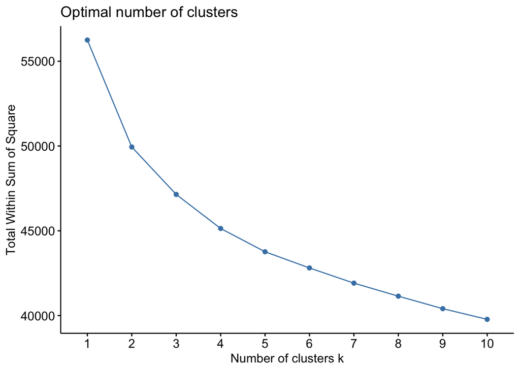

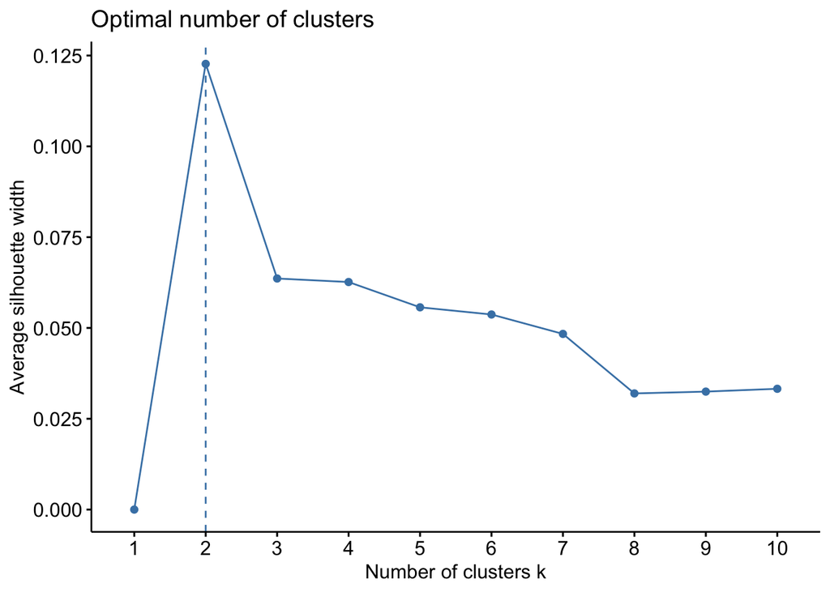

The dataset with clusters:

```
##       FSA       Rural_FSA       Region       Age         Gender
##  T3K    :  10   No :1416   Atlantic:308   18-34:329   Female:835
##  T5T    :  10   Yes: 159   BC      :304   35-54:599   Male  :738
##  B2W    :   9              Ontario :562   55+  :647   NA's  :  2
##  B3M    :   9              Prairies:401
##  T2Z    :   9
##  E1A    :   8
##  (Other):1520
##      Education   Children                 Religion
##  Advanced :212   No  :710   Not important     :774
##  Bachelors:561   Yes :863   Somewhat important:438
##  College  :301   NA's:  2   Very important    :312
##  HS       :399              NA's              : 51
##  Trades   :102
##
##
##                            Politics_Spectrum Born_Current_City
##  Both conservative and liberal views:732     No  :911
##  Conservative views                 :330     Yes :601
##  Progressive/liberal views          :513     NA's: 63
##
##
##
##
##  Born_Current_Province Born_Current_Country
##  No  : 477             No  : 254
##  Yes :1040             Yes :1263
##  NA's:  58             NA's:  58
##
##
##
##
##                                                        Born_Parents
##  All parents born in Canada                                  :888
##  All parents born outside Canada                             :519
##  Don’t know                                                  :  2
##  One parent born in Canada and one parent born outside Canada:151
##  Prefer not to say                                           : 15
##
##
```

[output cut: 81 more lines]

```
##  I seek to find common understanding with others, even if we have different beliefs               :1164
##  Some people’s beliefs are so unlike mine that I don’t think we could ever have anything in common: 411
##
##
##
##
##
##  sup_grp
##  1:1072
##  2: 503
##
##
##
##
##
```

## 1.1. Description of the 2 clusters by 20 value variables

### By plots with unweighted data

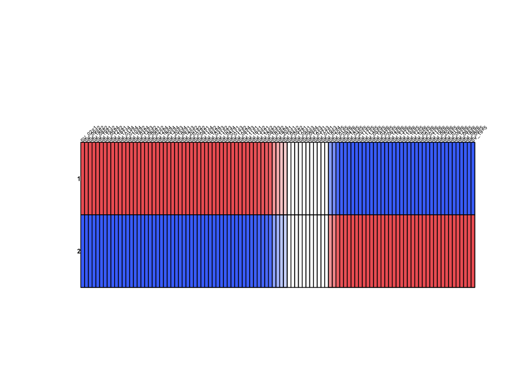

Note: The red color is for significantly positive associations between the clusters with responses, for example cluster 2 positively associated with responses of 5 and 6 for many SV questions, which means the proportions of participants chose these responses are significantly higher in the Cluster 2 than the global (averages)… The darker the color is, the smaller the p-value of the v-test is. From this, we can identify characteristics of each cluster and how the variables associated with each other.

### By statistical results with unweighted data

```
##
## Link between the cluster variable and the categorical variables (chi-square test)
## =================================================================================
##            p.value df
## SV_19 2.113509e-86  5
## SV_08 3.307144e-81  5
## SV_09 2.174332e-79  5
## SV_18 5.147034e-74  5
## SV_02 1.020809e-64  5
## SV_12 1.635411e-58  5
## SV_06 7.229137e-51  5
## SV_20 8.106403e-45  5
## SV_07 8.288040e-44  5
## SV_01 2.220712e-42  5
## SV_16 9.766067e-39  5
## SV_11 1.697808e-38  5
## SV_15 1.134524e-36  5
## SV_13 5.565795e-31  5
## SV_17 5.434988e-30  5
## SV_10 2.532048e-27  5
## SV_03 7.455110e-25  5
## SV_14 3.227414e-23  5
## SV_05 1.459424e-19  5
## SV_04 1.310086e-07  5
##
## Description of each cluster by the categories
## =============================================
## $`1`
##           Cla/Mod    Mod/Cla     Global      p.value     v.test
## SV_02=1 87.169043 39.9253731 31.1746032 1.420419e-30  11.493614
## SV_09=2 88.131313 32.5559701 25.1428571 7.664596e-26  10.511280
## SV_19=2 84.830339 39.6455224 31.8095238 3.974202e-24  10.132245
## SV_08=2 88.252149 28.7313433 22.1587302 1.514680e-22   9.769989
## SV_19=1 90.416667 20.2425373 15.2380952 1.892846e-18   8.763497
## SV_15=2 94.557823 12.9664179  9.3333333 3.287211e-16   8.162294
## SV_05=4 89.380531 18.8432836 14.3492063 1.069640e-15   8.018592
## SV_12=2 90.000000 17.6305970 13.3333333 1.948030e-15   7.944610
## SV_18=1 87.692308 21.2686567 16.5079365 2.202027e-15   7.929403
## SV_17=4 84.911243 26.7723881 21.4603175 3.756477e-15   7.862798
## SV_01=4 87.866109 19.5895522 15.1746032 2.469393e-14   7.623473
```

[output cut: 187 more lines]

```
## SV_03=4 13.362069  6.1630219 14.7301587 2.928518e-12  -6.981112
## SV_18=2 18.577982 16.1033797 27.6825397 4.212382e-13  -7.248556
## SV_10=4 12.121212  5.5666004 14.6666667 7.423949e-14  -7.480147
## SV_07=4 17.326733 13.9165010 25.6507937 3.740830e-14  -7.569701
## SV_01=4 12.133891  5.7654076 15.1746032 2.469393e-14  -7.623473
## SV_17=4 15.088757 10.1391650 21.4603175 3.756477e-15  -7.862798
## SV_18=1 12.307692  6.3618290 16.5079365 2.202027e-15  -7.929403
## SV_12=2 10.000000  4.1749503 13.3333333 1.948030e-15  -7.944610
## SV_05=4 10.619469  4.7713718 14.3492063 1.069640e-15  -8.018592
## SV_15=2  5.442177  1.5904573  9.3333333 3.287211e-16  -8.162294
## SV_19=1  9.583333  4.5725646 15.2380952 1.892846e-18  -8.763497
## SV_08=2 11.747851  8.1510934 22.1587302 1.514680e-22  -9.769989
## SV_19=2 15.169661 15.1093439 31.8095238 3.974202e-24 -10.132245
## SV_09=2 11.868687  9.3439364 25.1428571 7.664596e-26 -10.511280
## SV_02=1 12.830957 12.5248509 31.1746032 1.420419e-30 -11.493614
```

### By plots with weighted data

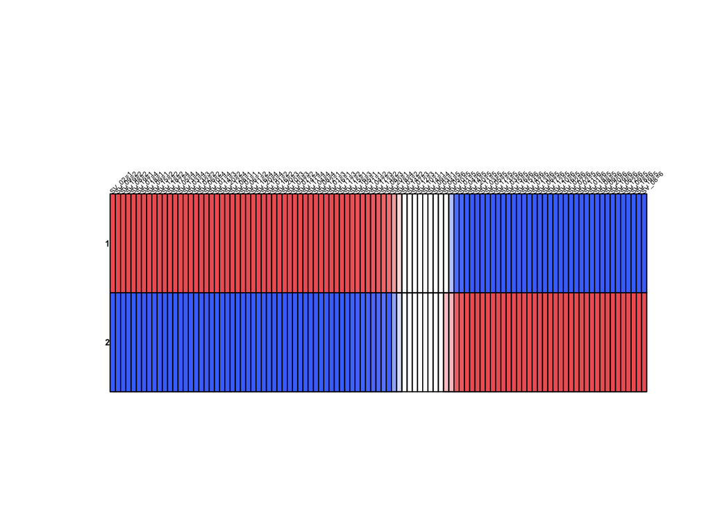

### By statistical results with weighted data

```
##
## Link between the cluster variable and the categorical variables (chi-square test)
## =================================================================================
##            p.value df
## SV_19 3.490328e-91  5
## SV_08 5.714179e-89  5
## SV_09 2.286949e-80  5
## SV_18 3.306085e-75  5
## SV_02 6.600850e-64  5
## SV_12 6.038269e-61  5
## SV_06 4.194280e-54  5
## SV_07 1.301617e-45  5
## SV_20 4.056776e-45  5
## SV_16 4.086418e-40  5
## SV_11 9.849103e-40  5
## SV_01 5.260983e-39  5
## SV_15 1.074353e-35  5
## SV_13 1.778310e-30  5
## SV_17 9.720449e-29  5
## SV_10 3.975063e-26  5
## SV_03 1.280358e-24  5
## SV_14 1.799578e-23  5
## SV_05 3.516778e-16  5
## SV_04 3.605493e-09  5
##
## Description of each cluster by the categories
## =============================================
## $`1`
##          Cla/Mod   Mod/Cla    Global      p.value     v.test
## SV_02=1 86.95010 41.589846 33.268007 7.925742e-29  11.140963
## SV_09=2 89.75123 32.264032 25.002749 1.119962e-26  10.691132
## SV_19=2 86.77907 37.844698 30.331898 5.794846e-25  10.318791
## SV_08=2 89.61138 28.881763 22.416617 2.942464e-23   9.934637
## SV_19=1 91.09143 21.372372 16.318669 4.225176e-19   8.930910
## SV_07=4 86.11628 30.508814 24.640505 9.964655e-18   8.574352
## SV_18=1 89.59597 21.926771 17.021418 3.487369e-17   8.428965
## SV_09=1 97.14089 11.019769  7.890054 1.123098e-16   8.290990
## SV_15=2 96.37668 11.852019  8.553225 3.957830e-16   8.139845
## SV_12=2 90.74577 17.644892 13.523906 4.991456e-15   7.827127
## SV_18=2 83.36529 33.518530 27.964641 1.159630e-14   7.720402
```

[output cut: 183 more lines]

```
## SV_13=4 12.470510  6.38398846 15.587153 2.183008e-12  -7.022265
## SV_03=4 12.541926  6.42606740 15.600552 1.648926e-12  -7.061350
## SV_05=4 10.568476  4.74284709 13.664247 2.579933e-13  -7.314681
## SV_17=4 13.843667  9.10327656 20.021912 6.317123e-14  -7.501335
## SV_18=2 16.634711 15.27796673 27.964641 1.159630e-14  -7.720402
## SV_12=2  9.254227  4.11039324 13.523906 4.991456e-15  -7.827127
## SV_09=1  2.859115  0.74088816  7.890054 1.720181e-15  -7.960015
## SV_15=2  3.623316  1.01783454  8.553225 3.957830e-16  -8.139845
## SV_18=1 10.404027  5.81618592 17.021418 3.487369e-17  -8.428965
## SV_07=4 13.883719 11.23560525 24.640505 9.964655e-18  -8.574352
## SV_19=1  8.908567  4.77456339 16.318669 4.225176e-19  -8.930910
## SV_08=2 10.388620  7.64837172 22.416617 2.942464e-23  -9.934637
## SV_19=2 13.220930 13.17051160 30.331898 5.794846e-25 -10.318791
## SV_09=2 10.248766  8.41589678 25.002749 2.160730e-27 -10.842669
## SV_02=1 13.049903 14.25854177 33.268007 7.925742e-29 -11.140963
```

## 1.2. Description of the 2 clusters by demographic varibales

### By plots with unweighted data

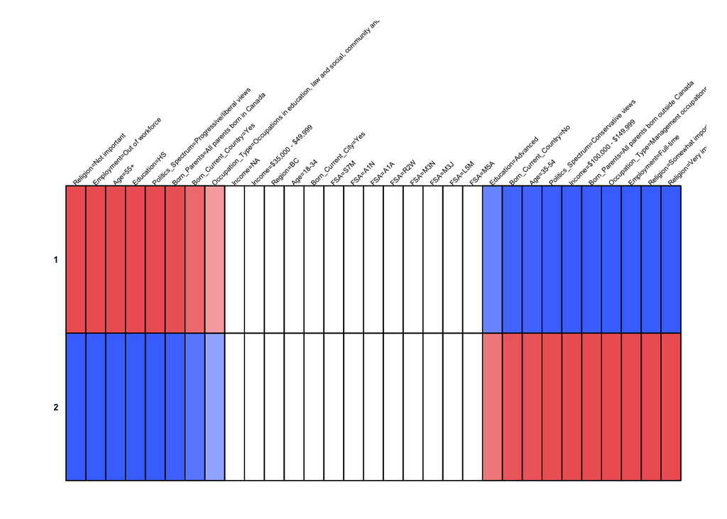

### By statistical results with unweighted data

```
##
## Link between the cluster variable and the categorical variables (chi-square test)
## =================================================================================
##                           p.value df
## Religion             2.121282e-34  3
## Employment           3.929059e-07  3
## Age                  1.950992e-06  2
## Politics_Spectrum    6.135852e-06  2
## Income               6.441251e-05  7
## Education            7.815295e-05  4
## Born_Parents         8.651935e-04  4
## Occupation_Type      9.030703e-04  9
## Born_Current_Country 2.092760e-03  2
##
## Description of each cluster by the categories
## =============================================
## $`1`
##                                                                                              Cla/Mod
## Religion=Not important                                                                      82.29974
## Employment=Out of workforce                                                                 76.06112
## Age=55+                                                                                     75.27048
## Education=HS                                                                                76.69173
## Politics_Spectrum=Progressive/liberal views                                                 75.24366
## Born_Parents=All parents born in Canada                                                     71.84685
## Born_Current_Country=Yes                                                                    69.91291
## Occupation_Type=Occupations in education, law and social, community and government services 75.28090
## Income=NA                                                                                   76.82119
## Income=$35,000 - $49,999                                                                    75.40984
## Region=BC                                                                                   73.35526
## Age=18-34                                                                                   63.52584
## Born_Current_City=Yes                                                                       65.05824
## FSA=S7M                                                                                     20.00000
## FSA=A1N                                                                                     20.00000
## FSA=A1A                                                                                     20.00000
## FSA=R2W                                                                                      0.00000
## FSA=M3N                                                                                      0.00000
## FSA=M3J                                                                                      0.00000
## FSA=L5M                                                                                      0.00000
## FSA=M5A                                                                                      0.00000
## Education=Advanced                                                                          58.96226
```

[output cut: 284 more lines]

```
## FSA=A1N                                                                                       2.035907
## FSA=A1A                                                                                       2.035907
## Born_Current_City=Yes                                                                         2.002194
## Age=18-34                                                                                     1.968268
## Region=BC                                                                                    -2.219667
## Income=$35,000 - $49,999                                                                     -2.296800
## Income=NA                                                                                    -2.469570
## Occupation_Type=Occupations in education, law and social, community and government services  -2.813425
## Born_Current_Country=Yes                                                                     -3.123042
## Born_Parents=All parents born in Canada                                                      -3.649615
## Politics_Spectrum=Progressive/liberal views                                                  -4.292039
## Education=HS                                                                                 -4.348921
## Age=55+                                                                                      -5.157449
## Employment=Out of workforce                                                                  -5.314799
## Religion=Not important                                                                      -12.064950
```

### By plots with weighted data

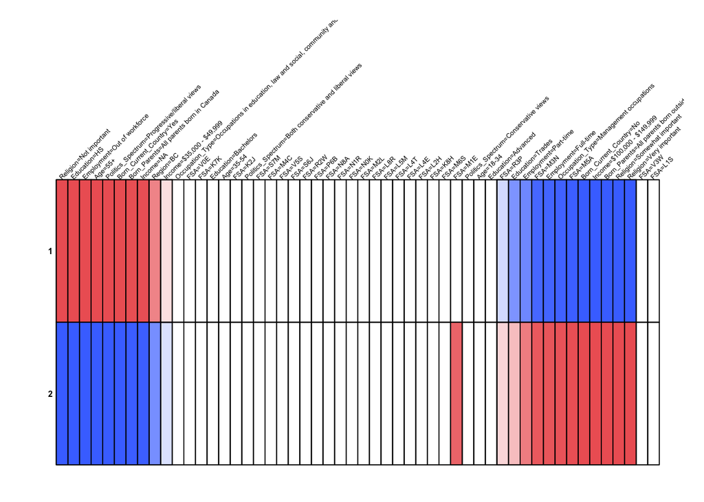

### By statistical results with weighted data

```
##
## Link between the cluster variable and the categorical variables (chi-square test)
## =================================================================================
##                           p.value  df
## Religion             2.953400e-30   3
## Employment           5.047749e-07   3
## Education            5.917069e-07   4
## Income               7.206126e-07   7
## Born_Current_Country 1.513127e-05   2
## Age                  2.273689e-05   2
## Politics_Spectrum    3.333980e-05   2
## Born_Parents         6.568895e-05   4
## FSA                  1.558622e-04 704
## Occupation_Type      3.746197e-02   9
## Region               4.272370e-02   3
##
## Description of each cluster by the categories
## =============================================
## $`1`
##                                                                                               Cla/Mod
## Religion=Not important                                                                       82.09992
## Education=HS                                                                                 76.42861
## Employment=Out of workforce                                                                  76.97831
## Age=55+                                                                                      76.60815
## Politics_Spectrum=Progressive/liberal views                                                  76.86081
## Born_Current_Country=Yes                                                                     71.79284
## Born_Parents=All parents born in Canada                                                      73.35585
## Income=NA                                                                                    82.35707
## Region=BC                                                                                    76.72235
## Income=$35,000 - $49,999                                                                     77.52143
## Occupation_Type=Occupations in education, law and social, community and government services  75.61299
## FSA=V0E                                                                                     100.00000
## FSA=K7K                                                                                     100.00000
## Education=Bachelors                                                                          64.29420
## Age=35-54                                                                                    65.88787
## FSA=K2J                                                                                      14.01702
## Politics_Spectrum=Both conservative and liberal views                                        66.83884
## FSA=S7M                                                                                      27.47465
## FSA=M4C                                                                                      28.69293
## FSA=V5S                                                                                      16.00391
```

[output cut: 476 more lines]

```
## Politics_Spectrum=Both conservative and liberal views                                         2.112319
## FSA=K2J                                                                                       2.108526
## Occupation_Type=Occupations in education, law and social, community and government services  -2.015867
## FSA=V0E                                                                                      -2.079525
## FSA=K7K                                                                                      -2.079525
## Income=$35,000 - $49,999                                                                     -2.608876
## Region=BC                                                                                    -2.926514
## Income=NA                                                                                    -3.718602
## Born_Parents=All parents born in Canada                                                      -3.785653
## Born_Current_Country=Yes                                                                     -4.156433
## Politics_Spectrum=Progressive/liberal views                                                  -4.481007
## Age=55+                                                                                      -4.618950
## Employment=Out of workforce                                                                  -5.283093
## Education=HS                                                                                 -5.414313
## Religion=Not important                                                                      -11.135593
```

## 1.3. Description of the 2 clusters by conflict varibales

### By plots with unweighted data

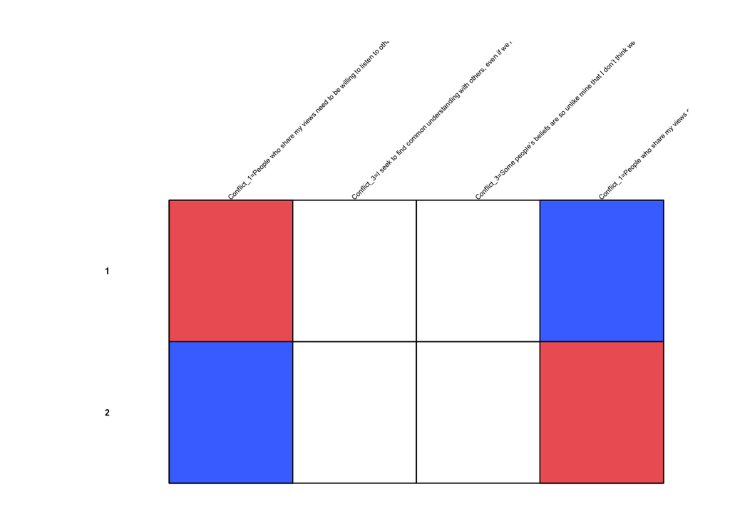

### By statistical results with unweighted data

```
##
## Link between the cluster variable and the categorical variables (chi-square test)
## =================================================================================
##                 p.value df
## Conflict_1 8.616667e-11  1
## Conflict_3 2.108857e-02  1
##
## Description of each cluster by the categories
## =============================================
## $`1`
##                                                                                                               Cla/Mod
## Conflict_1=People who share my views need to be willing to listen to others and compromise                   73.49282
## Conflict_3=I seek to find common understanding with others, even if we have different beliefs                69.67354
## Conflict_3=Some people’s beliefs are so unlike mine that I don’t think we could ever have anything in common 63.50365
## Conflict_1=People who share my views should stick to their beliefs and fight for what they believe in        57.35849
##                                                                                                               Mod/Cla
## Conflict_1=People who share my views need to be willing to listen to others and compromise                   71.64179
## Conflict_3=I seek to find common understanding with others, even if we have different beliefs                75.65299
## Conflict_3=Some people’s beliefs are so unlike mine that I don’t think we could ever have anything in common 24.34701
## Conflict_1=People who share my views should stick to their beliefs and fight for what they believe in        28.35821
##                                                                                                                Global
## Conflict_1=People who share my views need to be willing to listen to others and compromise                   66.34921
## Conflict_3=I seek to find common understanding with others, even if we have different beliefs                73.90476
## Conflict_3=Some people’s beliefs are so unlike mine that I don’t think we could ever have anything in common 26.09524
## Conflict_1=People who share my views should stick to their beliefs and fight for what they believe in        33.65079
##                                                                                                                   p.value
## Conflict_1=People who share my views need to be willing to listen to others and compromise                   1.396591e-10
## Conflict_3=I seek to find common understanding with others, even if we have different beliefs                2.210288e-02
## Conflict_3=Some people’s beliefs are so unlike mine that I don’t think we could ever have anything in common 2.210288e-02
## Conflict_1=People who share my views should stick to their beliefs and fight for what they believe in        1.396591e-10
##                                                                                                                 v.test
## Conflict_1=People who share my views need to be willing to listen to others and compromise                    6.416264
## Conflict_3=I seek to find common understanding with others, even if we have different beliefs                 2.288595
## Conflict_3=Some people’s beliefs are so unlike mine that I don’t think we could ever have anything in common -2.288595
## Conflict_1=People who share my views should stick to their beliefs and fight for what they believe in        -6.416264
##
## $`2`
##                                                                                                               Cla/Mod
## Conflict_1=People who share my views should stick to their beliefs and fight for what they believe in        42.64151
## Conflict_3=Some people’s beliefs are so unlike mine that I don’t think we could ever have anything in common 36.49635
## Conflict_3=I seek to find common understanding with others, even if we have different beliefs                30.32646
```

[output cut: 21 more lines]

### By plots with weighted data

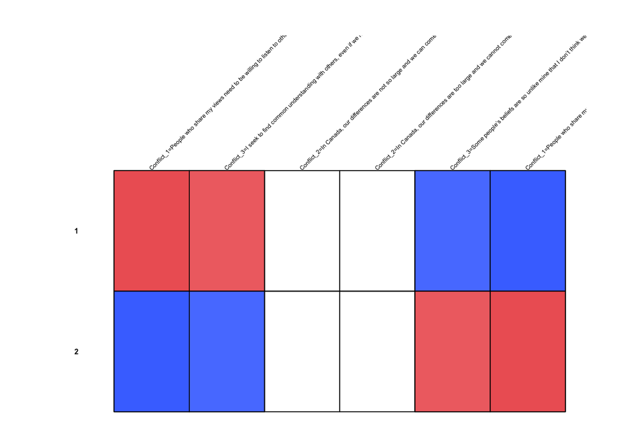

### By statistical results with weighted data

```
##
## Link between the cluster variable and the categorical variables (chi-square test)
## =================================================================================
##                 p.value df
## Conflict_1 2.996485e-09  1
## Conflict_3 7.209530e-04  1
## Conflict_2 4.466343e-02  1
##
## Description of each cluster by the categories
## =============================================
## $`1`
##                                                                                                               Cla/Mod
## Conflict_1=People who share my views need to be willing to listen to others and compromise                   74.69536
## Conflict_3=I seek to find common understanding with others, even if we have different beliefs                71.92508
## Conflict_2=In Canada, our differences are not so large and we can come together                              70.64548
## Conflict_2=In Canada, our differences are too large and we cannot come together                              64.59501
## Conflict_3=Some people’s beliefs are so unlike mine that I don’t think we could ever have anything in common 63.07328
## Conflict_1=People who share my views should stick to their beliefs and fight for what they believe in        60.35360
##                                                                                                               Mod/Cla
## Conflict_1=People who share my views need to be willing to listen to others and compromise                   68.88003
## Conflict_3=I seek to find common understanding with others, even if we have different beliefs                75.68811
## Conflict_2=In Canada, our differences are not so large and we can come together                              83.21519
## Conflict_2=In Canada, our differences are too large and we cannot come together                              16.78481
## Conflict_3=Some people’s beliefs are so unlike mine that I don’t think we could ever have anything in common 24.31189
## Conflict_1=People who share my views should stick to their beliefs and fight for what they believe in        31.11997
##                                                                                                                Global
## Conflict_1=People who share my views need to be willing to listen to others and compromise                   64.13709
## Conflict_3=I seek to find common understanding with others, even if we have different beliefs                73.19087
## Conflict_2=In Canada, our differences are not so large and we can come together                              81.92713
## Conflict_2=In Canada, our differences are too large and we cannot come together                              18.07287
## Conflict_3=Some people’s beliefs are so unlike mine that I don’t think we could ever have anything in common 26.80913
## Conflict_1=People who share my views should stick to their beliefs and fight for what they believe in        35.86291
##                                                                                                                   p.value
## Conflict_1=People who share my views need to be willing to listen to others and compromise                   2.414207e-09
## Conflict_3=I seek to find common understanding with others, even if we have different beliefs                8.188592e-04
## Conflict_2=In Canada, our differences are not so large and we can come together                              3.325355e-02
## Conflict_2=In Canada, our differences are too large and we cannot come together                              4.657697e-02
## Conflict_3=Some people’s beliefs are so unlike mine that I don’t think we could ever have anything in common 8.188592e-04
## Conflict_1=People who share my views should stick to their beliefs and fight for what they believe in        4.776898e-09
##                                                                                                                 v.test
```

[output cut: 28 more lines]

```
## Conflict_1=People who share my views need to be willing to listen to others and compromise                   64.13709
##                                                                                                                   p.value
## Conflict_1=People who share my views should stick to their beliefs and fight for what they believe in        4.776898e-09
## Conflict_3=Some people’s beliefs are so unlike mine that I don’t think we could ever have anything in common 8.188592e-04
## Conflict_2=In Canada, our differences are too large and we cannot come together                              4.657697e-02
## Conflict_2=In Canada, our differences are not so large and we can come together                              4.657697e-02
## Conflict_3=I seek to find common understanding with others, even if we have different beliefs                8.188592e-04
## Conflict_1=People who share my views need to be willing to listen to others and compromise                   4.776898e-09
##                                                                                                                 v.test
## Conflict_1=People who share my views should stick to their beliefs and fight for what they believe in         5.854763
## Conflict_3=Some people’s beliefs are so unlike mine that I don’t think we could ever have anything in common  3.346340
## Conflict_2=In Canada, our differences are too large and we cannot come together                               1.990127
## Conflict_2=In Canada, our differences are not so large and we can come together                              -1.990127
## Conflict_3=I seek to find common understanding with others, even if we have different beliefs                -3.346340
## Conflict_1=People who share my views need to be willing to listen to others and compromise                   -5.854763
```

# 2. Description of conflict 1 groups by other variables

## 2.1. By demographic varibles

### By plots with unweighted data

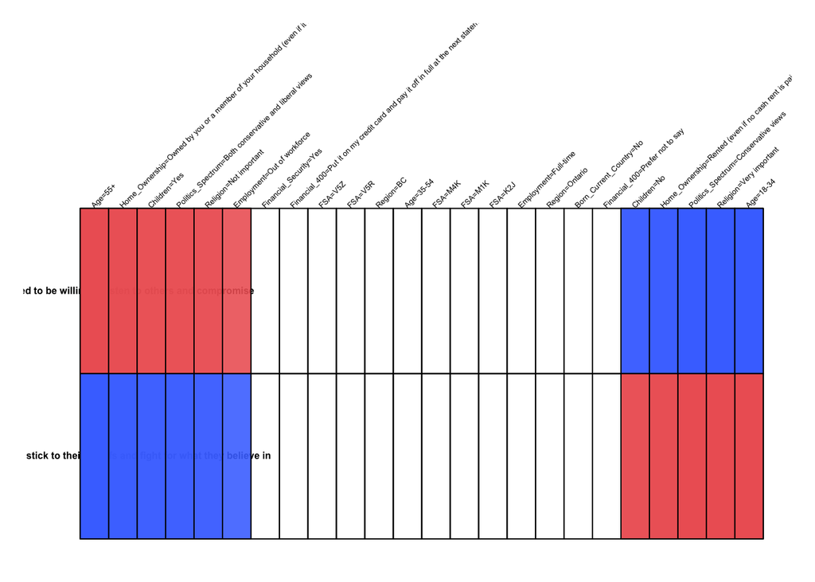

### By statictical results with unweighted data

```
##
## Link between the cluster variable and the categorical variables (chi-square test)
## =================================================================================
##                           p.value df
## Age                  4.163237e-12  2
## Politics_Spectrum    2.961365e-07  2
## Religion             8.854997e-07  3
## Home_Ownership       2.005815e-04  1
## Children             1.553828e-03  2
## Employment           1.308847e-02  3
## Region               2.764692e-02  3
## Financial_Security   3.103626e-02  2
## Born_Current_Country 4.378519e-02  2
## Financial_400        4.953788e-02  9
##
## Description of each cluster by the categories
## =============================================
## $`People who share my views need to be willing to listen to others and compromise`
##                                                                                                   Cla/Mod
## Age=55+                                                                                          75.73416
## Home_Ownership=Owned by you or a member of your household (even if it is still being paid for)?  69.16221
## Children=Yes                                                                                     70.22016
## Politics_Spectrum=Both conservative and liberal views                                            70.90164
## Religion=Not important                                                                           70.54264
## Employment=Out of workforce                                                                      71.30730
## Financial_Security=Yes                                                                           68.42601
## Financial_400=Put it on my credit card and pay it off in full at the next statement              69.72892
## FSA=V5Z                                                                                         100.00000
## FSA=V5R                                                                                         100.00000
## Region=BC                                                                                        71.38158
## Age=35-54                                                                                        63.27212
## FSA=M4K                                                                                           0.00000
## FSA=M1K                                                                                           0.00000
## FSA=K2J                                                                                           0.00000
## Employment=Full-time                                                                             63.29305
## Region=Ontario                                                                                   62.81139
## Born_Current_Country=No                                                                          60.23622
## Financial_400=Prefer not to say                                                                  50.00000
## Children=No                                                                                      61.69014
## Home_Ownership=Rented (even if no cash rent is paid)?                                            59.38190
```

[output cut: 215 more lines]

```
## FSA=M4K                                                                                          2.075263
## FSA=M1K                                                                                          2.075263
## FSA=K2J                                                                                          2.075263
## Age=35-54                                                                                        2.017803
## Region=BC                                                                                       -2.078919
## FSA=V5Z                                                                                         -2.083363
## FSA=V5R                                                                                         -2.083363
## Financial_400=Put it on my credit card and pay it off in full at the next statement             -2.425395
## Financial_Security=Yes                                                                          -2.492289
## Employment=Out of workforce                                                                     -3.230844
## Religion=Not important                                                                          -3.461340
## Politics_Spectrum=Both conservative and liberal views                                           -3.566025
## Children=Yes                                                                                    -3.571055
## Home_Ownership=Owned by you or a member of your household (even if it is still being paid for)? -3.683505
## Age=55+                                                                                         -6.643149
```

### By plots with weighted data

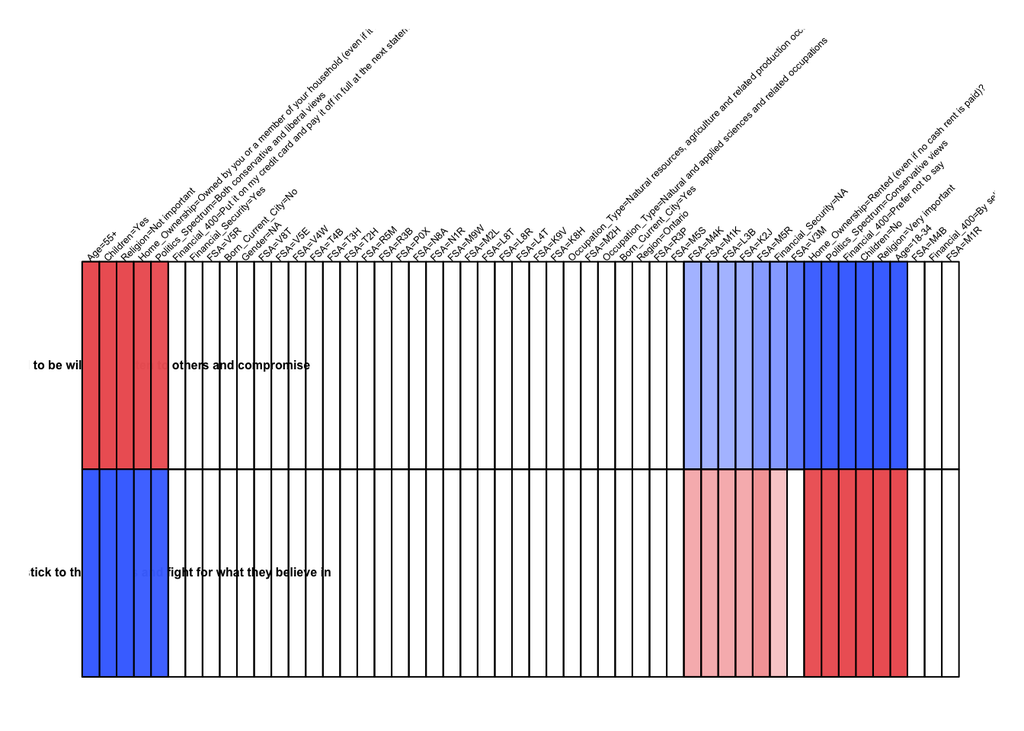

### By statictical results with weighted data

```
##
## Link between the cluster variable and the categorical variables (chi-square test)
## =================================================================================
##                         p.value  df
## Age                7.905095e-13   2
## Religion           5.019556e-09   3
## Children           5.099578e-06   2
## Politics_Spectrum  1.003939e-04   2
## Home_Ownership     2.791121e-04   1
## Financial_400      8.283865e-04   9
## FSA                3.002451e-03 704
## Financial_Security 7.756309e-03   2
## Occupation_Type    2.431725e-02   9
## Gender             2.458144e-02   2
##
## Description of each cluster by the categories
## =============================================
## $`People who share my views need to be willing to listen to others and compromise`
##                                                                                                    Cla/Mod
## Age=55+                                                                                          74.646270
## Children=Yes                                                                                     70.002008
## Religion=Not important                                                                           69.724811
## Home_Ownership=Owned by you or a member of your household (even if it is still being paid for)?  67.295120
## Politics_Spectrum=Both conservative and liberal views                                            68.834028
## Financial_400=Put it on my credit card and pay it off in full at the next statement              68.043108
## Financial_Security=Yes                                                                           66.345412
## FSA=V5R                                                                                         100.000000
## Born_Current_City=No                                                                             66.379395
## Gender=NA                                                                                         0.000000
## FSA=V8T                                                                                          13.324896
## FSA=V5E                                                                                          17.805992
## FSA=V4W                                                                                           0.000000
## FSA=T4B                                                                                          14.365160
## FSA=T3H                                                                                          13.792843
## FSA=T2H                                                                                           0.000000
## FSA=R5M                                                                                           0.000000
## FSA=R3B                                                                                           0.000000
## FSA=P0X                                                                                           0.000000
## FSA=N8A                                                                                           0.000000
## FSA=N1R                                                                                           0.000000
```

[output cut: 460 more lines]

```
## FSA=M1R                                                                                          1.995331
## FSA=L8T                                                                                          1.995331
## FSA=L8R                                                                                          1.995331
## FSA=L4T                                                                                          1.995331
## FSA=K9V                                                                                          1.995331
## FSA=K8H                                                                                          1.995331
## Born_Current_City=No                                                                            -2.016649
## FSA=V5R                                                                                         -2.192918
## Financial_Security=Yes                                                                          -2.309174
## Financial_400=Put it on my credit card and pay it off in full at the next statement             -2.417819
## Politics_Spectrum=Both conservative and liberal views                                           -3.550721
## Home_Ownership=Owned by you or a member of your household (even if it is still being paid for)? -3.565690
## Religion=Not important                                                                          -4.726189
## Children=Yes                                                                                    -4.966851
## Age=55+                                                                                         -6.653845
```

## 2.2. By value varibles

### By plots with unweighted data

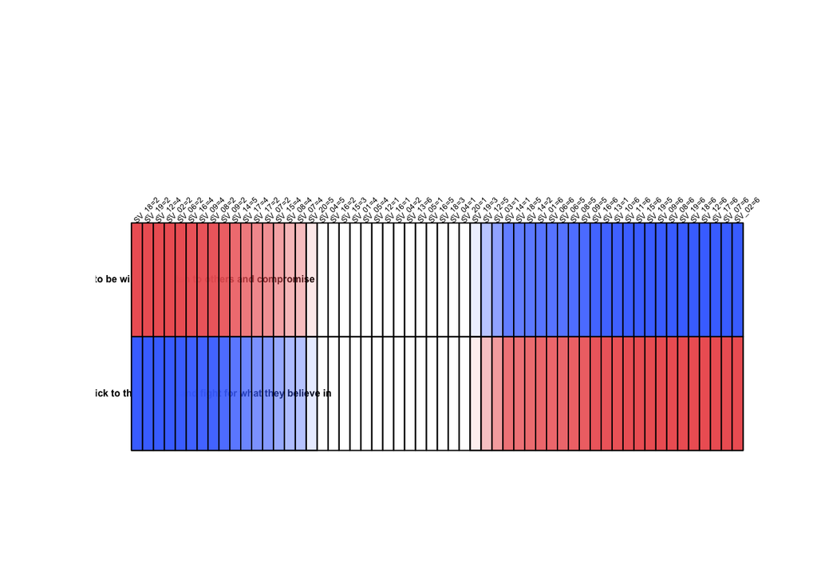

### By statictical results with unweighted data

```
##
## Link between the cluster variable and the categorical variables (chi-square test)
## =================================================================================
##            p.value df
## SV_19 1.014660e-13  5
## SV_18 7.614537e-13  5
## SV_12 1.705757e-11  5
## SV_02 3.105020e-11  5
## SV_07 6.705810e-10  5
## SV_17 1.585468e-09  5
## SV_09 4.211105e-09  5
## SV_08 1.981894e-08  5
## SV_16 1.590236e-06  5
## SV_06 1.731526e-06  5
## SV_14 1.960329e-05  5
## SV_15 1.227701e-04  5
## SV_13 9.062358e-04  5
## SV_04 2.963383e-03  5
## SV_10 3.811125e-03  5
## SV_11 4.044918e-03  5
## SV_01 5.574232e-03  5
## SV_20 7.605934e-03  5
## SV_03 2.298898e-02  5
##
## Description of each cluster by the categories
## =============================================
## $`People who share my views need to be willing to listen to others and compromise`
##          Cla/Mod    Mod/Cla     Global      p.value    v.test
## SV_18=2 77.75229 32.4401914 27.6825397 1.453458e-09  6.049445
## SV_19=2 76.64671 36.7464115 31.8095238 1.946345e-09  6.002223
## SV_12=4 77.86667 27.9425837 23.8095238 3.172467e-08  5.531642
## SV_02=2 78.33333 22.4880383 19.0476190 5.446314e-07  5.009883
## SV_06=2 74.05660 30.0478469 26.9206349 7.032974e-05  3.975167
## SV_16=4 74.14773 24.9760766 22.3492063 3.716584e-04  3.559432
## SV_09=4 74.00000 24.7846890 22.2222222 5.052501e-04  3.477957
## SV_08=2 73.92550 24.6889952 22.1587302 5.879118e-04  3.437131
## SV_09=2 72.97980 27.6555024 25.1428571 1.120580e-03  3.258360
## SV_14=5 71.80527 33.8755981 31.3015873 1.860422e-03  3.111654
## SV_17=4 73.07692 23.6363636 21.4603175 2.845551e-03  2.983948
## SV_17=2 78.15126  8.8995215  7.5555556 3.690078e-03  2.903508
```

[output cut: 88 more lines]

```
## SV_08=4 27.12418 15.660377 19.4285714 6.564392e-03 -2.718171
## SV_15=4 27.45665 17.924528 21.9682540 5.357107e-03 -2.784738
## SV_07=2 25.33937 10.566038 14.0317460 4.209511e-03 -2.862019
## SV_17=2 21.84874  4.905660  7.5555556 3.690078e-03 -2.903508
## SV_17=4 26.92308 17.169811 21.4603175 2.845551e-03 -2.983948
## SV_14=5 28.19473 26.226415 31.3015873 1.860422e-03 -3.111654
## SV_09=2 27.02020 20.188679 25.1428571 1.120580e-03 -3.258360
## SV_08=2 26.07450 17.169811 22.1587302 5.879118e-04 -3.437131
## SV_09=4 26.00000 17.169811 22.2222222 5.052501e-04 -3.477957
## SV_16=4 25.85227 17.169811 22.3492063 3.716584e-04 -3.559432
## SV_06=2 25.94340 20.754717 26.9206349 7.032974e-05 -3.975167
## SV_02=2 21.66667 12.264151 19.0476190 5.446314e-07 -5.009883
## SV_12=4 22.13333 15.660377 23.8095238 3.172467e-08 -5.531642
## SV_19=2 23.35329 22.075472 31.8095238 1.946345e-09 -6.002223
## SV_18=2 22.24771 18.301887 27.6825397 1.453458e-09 -6.049445
```

### By plots with weighted data

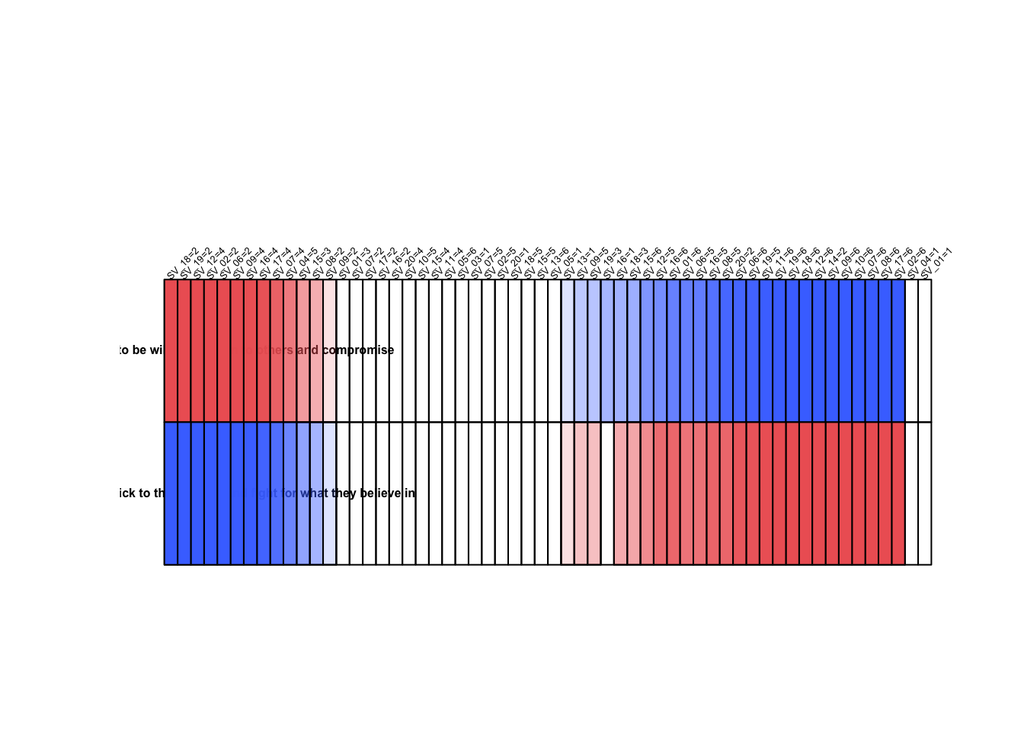

### By statictical results with weighted data

```
##
## Link between the cluster variable and the categorical variables (chi-square test)
## =================================================================================
##            p.value df
## SV_02 1.492568e-12  5
## SV_19 1.016337e-10  5
## SV_18 3.400041e-09  5
## SV_12 3.916376e-09  5
## SV_09 1.470203e-08  5
## SV_08 5.222369e-08  5
## SV_07 5.113566e-07  5
## SV_16 5.509125e-07  5
## SV_17 1.008150e-06  5
## SV_06 2.125889e-06  5
## SV_14 2.572367e-05  5
## SV_10 4.458719e-04  5
## SV_20 9.815494e-04  5
## SV_15 1.320113e-03  5
## SV_11 2.220090e-03  5
## SV_01 3.163741e-03  5
## SV_13 5.827590e-03  5
## SV_04 7.692940e-03  5
##
## Description of each cluster by the categories
## =============================================
## $`People who share my views need to be willing to listen to others and compromise`
##          Cla/Mod    Mod/Cla    Global      p.value    v.test
## SV_18=2 74.71743 32.5778113 27.964641 2.541842e-08  5.570380
## SV_19=2 74.09715 35.0422357 30.331898 3.875148e-08  5.496449
## SV_12=4 74.84141 26.8120852 22.977243 7.930734e-07  4.937064
## SV_02=2 76.15721 22.0187960 18.543505 1.591491e-06  4.799391
## SV_06=2 72.60635 29.8724154 26.387911 2.174712e-05  4.246154
## SV_09=4 73.30916 23.9644116 20.966107 6.968330e-05  3.977365
## SV_16=4 72.41398 25.0378454 22.176031 1.858568e-04  3.737503
## SV_17=4 72.48293 22.6272626 20.021912 3.289863e-04  3.591337
## SV_07=4 70.84863 27.2189777 24.640505 1.287241e-03  3.218809
## SV_04=5 69.22236 35.8227667 33.191129 2.875703e-03  2.980721
## SV_15=3 69.47834 30.6699623 28.312165 4.924656e-03  2.811921
## SV_08=2 70.20630 24.5378700 22.416617 6.064279e-03  2.744285
## SV_09=2 69.55471 27.1147129 25.002749 9.256141e-03  2.602446
```

[output cut: 88 more lines]

```
## SV_07=2 28.84032 10.161669 12.6360241 2.172545e-02 -2.295134
## SV_01=3 30.43738 19.648251 23.1505959 1.255928e-02 -2.496028
## SV_09=2 30.44529 21.225719 25.0027486 9.256141e-03 -2.602446
## SV_08=2 29.79370 18.622977 22.4166173 6.064279e-03 -2.744285
## SV_15=3 30.52166 24.095489 28.3121650 4.924656e-03 -2.811921
## SV_04=5 30.77764 28.484717 33.1911288 2.875703e-03 -2.980721
## SV_07=4 29.15137 20.029173 24.6405048 1.287241e-03 -3.218809
## SV_17=4 27.51707 15.362512 20.0219117 5.488277e-04 -3.455719
## SV_16=4 27.58602 17.057971 22.1760306 1.858568e-04 -3.737503
## SV_09=4 26.69084 15.603950 20.9661070 6.968330e-05 -3.977365
## SV_06=2 27.39365 20.156237 26.3879112 2.174712e-05 -4.246154
## SV_02=2 23.84279 12.328306 18.5435046 1.591491e-06 -4.799391
## SV_12=4 25.15859 16.119026 22.9772432 7.930734e-07 -4.937064
## SV_19=2 25.90285 21.907948 30.3318984 3.875148e-08 -5.496449
## SV_18=2 25.28257 19.714464 27.9646409 2.541842e-08 -5.570380
```

# 3. Description of conflict 2 groups by other variables

## 3.1. By demographic varibles

### By plots with unweighted data

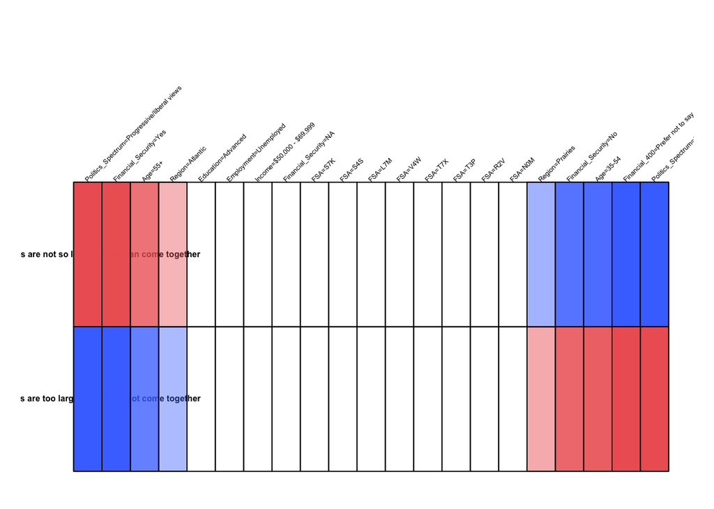

### By statictical results with unweighted data

```
##
## Link between the cluster variable and the categorical variables (chi-square test)
## =================================================================================
##                         p.value df
## Politics_Spectrum  3.556253e-14  2
## Financial_Security 1.238734e-04  2
## Financial_400      1.292406e-03  9
## Age                2.418409e-03  2
## Region             3.099053e-03  3
## Employment         2.629214e-02  3
## Education          3.927104e-02  4
##
## Description of each cluster by the categories
## =============================================
## $`In Canada, our differences are not so large and we can come together`
##                                              Cla/Mod    Mod/Cla     Global
## Politics_Spectrum=Progressive/liberal views 90.64327 35.1473923 32.5714286
## Financial_Security=Yes                      86.71065 69.5389267 67.3650794
## Age=55+                                     87.32612 42.7059713 41.0793651
## Region=Atlantic                             88.96104 20.7105064 19.5555556
## Education=Advanced                          89.62264 14.3613001 13.4603175
## Employment=Unemployed                       78.01418  8.3144369  8.9523810
## Income=$50,000 - $69,999                    79.69925 16.0241875 16.8888889
## Financial_Security=NA                       77.04918  7.1050642  7.7460317
## FSA=S7K                                     40.00000  0.1511716  0.3174603
## FSA=S4S                                     40.00000  0.1511716  0.3174603
## FSA=L7M                                     40.00000  0.1511716  0.3174603
## FSA=V4W                                      0.00000  0.0000000  0.1269841
## FSA=T7X                                      0.00000  0.0000000  0.1269841
## FSA=T3P                                      0.00000  0.0000000  0.1269841
## FSA=R2V                                      0.00000  0.0000000  0.1269841
## FSA=N0M                                      0.00000  0.0000000  0.1269841
## Region=Prairies                             79.55112 24.1118670 25.4603175
## Financial_Security=No                       78.82653 23.3560091 24.8888889
## Age=35-54                                   80.13356 36.2811791 38.0317460
## Financial_400=Prefer not to say             58.33333  2.1164021  3.0476190
## Politics_Spectrum=Conservative views        70.60606 17.6114890 20.9523810
##                                                  p.value    v.test
## Politics_Spectrum=Progressive/liberal views 2.285063e-07  5.174513
## Financial_Security=Yes                      3.621120e-05  4.130413
```

[output cut: 72 more lines]

```
## FSA=T7X                                      2.233521
## FSA=T3P                                      2.233521
## FSA=R2V                                      2.233521
## FSA=N0M                                      2.233521
## FSA=S7K                                      2.116168
## FSA=S4S                                      2.116168
## FSA=L7M                                      2.116168
## Financial_Security=NA                        2.089976
## Income=$50,000 - $69,999                     2.049969
## Employment=Unemployed                        1.960926
## Education=Advanced                          -2.482991
## Region=Atlantic                             -2.722587
## Age=55+                                     -3.028372
## Financial_Security=Yes                      -4.130413
## Politics_Spectrum=Progressive/liberal views -5.174513
```

### By plots with weighted data

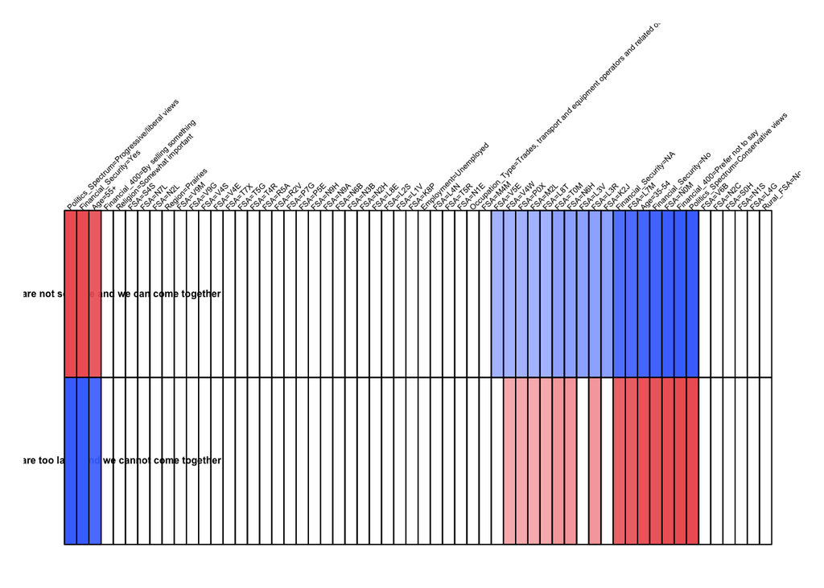

### By statictical results with weighted data

```
##
## Link between the cluster variable and the categorical variables (chi-square test)
## =================================================================================
##                         p.value  df
## Politics_Spectrum  3.720308e-13   2
## Financial_Security 2.688967e-07   2
## Financial_400      3.902565e-07   9
## FSA                6.833551e-06 704
## Age                5.306246e-04   2
## Region             3.260035e-02   3
##
## Description of each cluster by the categories
## =============================================
## $`In Canada, our differences are not so large and we can come together`
##                                                                                    Cla/Mod
## Politics_Spectrum=Progressive/liberal views                                       88.96982
## Financial_Security=Yes                                                            85.93493
## Age=55+                                                                           86.03468
## Financial_400=By selling something                                                95.35486
## Religion=Somewhat important                                                       85.02623
## FSA=S4S                                                                           34.01451
## FSA=N7L                                                                           47.74844
## FSA=N2L                                                                           38.00068
## Region=Prairies                                                                   78.27782
## FSA=V9M                                                                            0.00000
## FSA=V9G                                                                            0.00000
## FSA=V4S                                                                            0.00000
## FSA=V4E                                                                            0.00000
## FSA=T7X                                                                            0.00000
## FSA=T5G                                                                           17.88570
## FSA=T4R                                                                            0.00000
## FSA=R5A                                                                            0.00000
## FSA=R2V                                                                            0.00000
## FSA=P7G                                                                            0.00000
## FSA=P5E                                                                            0.00000
## FSA=N9H                                                                            0.00000
## FSA=N9A                                                                            0.00000
## FSA=N6B                                                                            0.00000
## FSA=N3B                                                                            0.00000
## FSA=N2H                                                                            0.00000
```

[output cut: 501 more lines]

```
## FSA=L2S                                                                            2.136366
## FSA=L1V                                                                            2.136366
## FSA=K8P                                                                            2.136366
## Region=Prairies                                                                    2.081876
## Employment=Unemployed                                                              2.008902
## FSA=S4S                                                                            1.972261
## FSA=N2L                                                                            1.972261
## FSA=L3V                                                                            1.972261
## FSA=K2J                                                                            1.972261
## Religion=Somewhat important                                                       -1.999916
## Rural_FSA=No                                                                      -2.073360
## Financial_400=By selling something                                                -2.106999
## Age=55+                                                                           -3.307922
## Politics_Spectrum=Progressive/liberal views                                       -5.222928
## Financial_Security=Yes                                                            -5.228418
```

## 3.2. By value varibles

### By plots with unweighted data

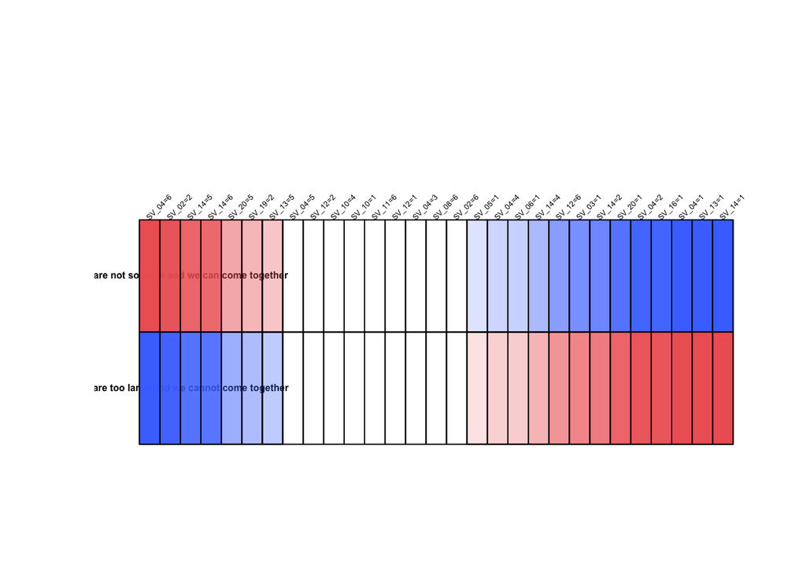

### By statictical results with unweighted data

```
##
## Link between the cluster variable and the categorical variables (chi-square test)
## =================================================================================
##            p.value df
## SV_14 2.248953e-15  5
## SV_04 1.120939e-12  5
## SV_13 4.605832e-06  5
## SV_20 2.367104e-04  5
## SV_16 2.059444e-03  5
## SV_12 3.222095e-03  5
## SV_05 3.878308e-03  5
## SV_02 3.972025e-03  5
## SV_06 7.472099e-03  5
## SV_03 9.263562e-03  5
## SV_10 2.427968e-02  5
## SV_19 2.771818e-02  5
##
## Description of each cluster by the categories
## =============================================
## $`In Canada, our differences are not so large and we can come together`
##          Cla/Mod    Mod/Cla     Global      p.value    v.test
## SV_04=6 89.08046 35.1473923 33.1428571 7.471289e-05  3.960756
## SV_02=2 90.33333 20.4837491 19.0476190 5.277190e-04  3.466277
## SV_14=5 88.23529 32.8798186 31.3015873 1.628356e-03  3.150779
## SV_14=6 88.97638 25.6235828 24.1904762 1.772758e-03  3.125877
## SV_20=5 87.64706 33.7868481 32.3809524 5.620166e-03  2.769156
## SV_19=2 87.62475 33.1821618 31.8095238 6.595737e-03  2.716594
## SV_13=5 87.23776 37.7173091 36.3174603 7.547428e-03  2.671672
## SV_04=5 86.83206 34.3915344 33.2698413 2.910142e-02  2.182110
## SV_12=2 88.57143 14.0589569 13.3333333 4.719174e-02  1.984575
## SV_10=4 88.31169 15.4195011 14.6666667 4.830598e-02  1.974667
## SV_10=1 62.50000  0.7558579  1.0158730 3.851396e-02 -2.069342
## SV_11=6 78.85463 13.5298564 14.4126984 2.647602e-02 -2.219157
## SV_12=1 73.97260  4.0816327  4.6349206 2.459004e-02 -2.247783
## SV_04=3 79.68254 18.9720333 20.0000000 2.238242e-02 -2.283815
## SV_08=6 76.37795  7.3318216  8.0634921 1.972506e-02 -2.331537
## SV_02=6 76.62338  8.9191232  9.7777778 1.197100e-02 -2.512998
## SV_05=1 56.25000  0.6802721  1.0158730 9.251069e-03 -2.602634
## SV_04=4 76.28205  8.9947090  9.9047619 8.226943e-03 -2.642611
## SV_06=1 77.27273 11.5646259 12.5714286 7.981063e-03 -2.652870
```

[output cut: 27 more lines]

```
## SV_08=6 23.622047 11.904762  8.0634921 1.972506e-02  2.331537
## SV_04=3 20.317460 25.396825 20.0000000 2.238242e-02  2.283815
## SV_12=1 26.027397  7.539683  4.6349206 2.459004e-02  2.247783
## SV_11=6 21.145374 19.047619 14.4126984 2.647602e-02  2.219157
## SV_10=1 37.500000  2.380952  1.0158730 3.851396e-02  2.069342
## SV_10=4 11.688312 10.714286 14.6666667 4.830598e-02 -1.974667
## SV_12=2 11.428571  9.523810 13.3333333 4.719174e-02 -1.984575
## SV_04=5 13.167939 27.380952 33.2698413 2.910142e-02 -2.182110
## SV_13=5 12.762238 28.968254 36.3174603 7.547428e-03 -2.671672
## SV_19=2 12.375250 24.603175 31.8095238 6.595737e-03 -2.716594
## SV_20=5 12.352941 25.000000 32.3809524 5.620166e-03 -2.769156
## SV_14=6 11.023622 16.666667 24.1904762 1.772758e-03 -3.125877
## SV_14=5 11.764706 23.015873 31.3015873 1.628356e-03 -3.150779
## SV_02=2  9.666667 11.507937 19.0476190 5.277190e-04 -3.466277
## SV_04=6 10.919540 22.619048 33.1428571 7.471289e-05 -3.960756
```

### By plots with weighted data

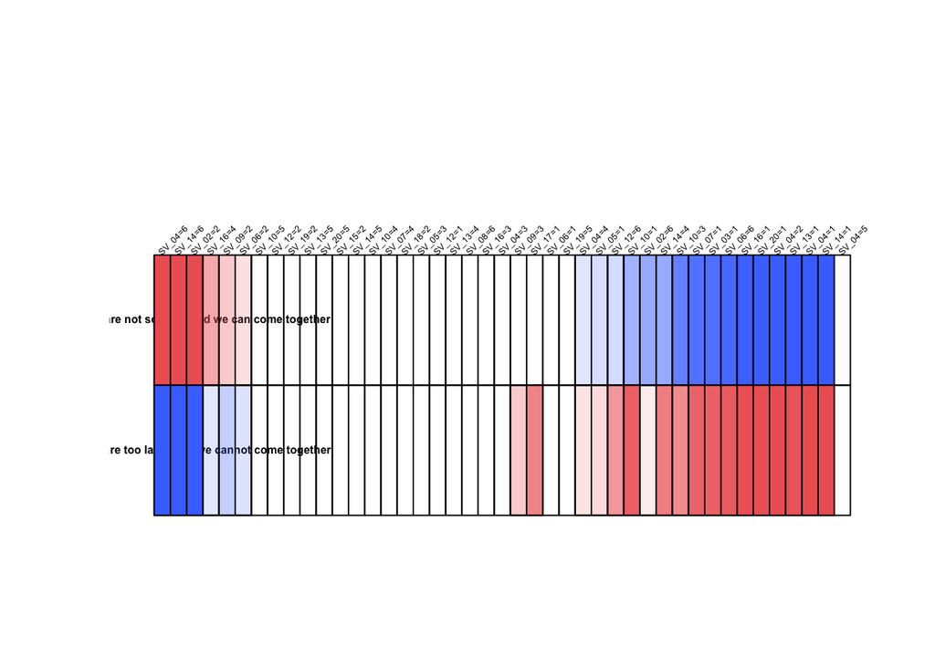

### By statictical results with weighted data

```
##
## Link between the cluster variable and the categorical variables (chi-square test)
## =================================================================================
##            p.value df
## SV_14 1.631849e-18  5
## SV_04 5.576476e-15  5
## SV_13 1.645069e-05  5
## SV_10 2.785908e-05  5
## SV_16 5.902591e-05  5
## SV_06 1.077896e-04  5
## SV_20 1.457242e-04  5
## SV_02 8.207600e-04  5
## SV_03 2.774418e-03  5
## SV_12 5.158911e-03  5
## SV_07 9.276310e-03  5
## SV_05 1.042103e-02  5
## SV_09 1.882734e-02  5
## SV_17 3.044773e-02  5
## SV_19 3.875327e-02  5
## SV_08 4.850650e-02  5
##
## Description of each cluster by the categories
## =============================================
## $`In Canada, our differences are not so large and we can come together`
##          Cla/Mod    Mod/Cla     Global      p.value    v.test
## SV_04=6 87.97287 36.4305916 33.9269812 3.836155e-06  4.620067
## SV_14=6 88.95630 26.7385644 24.6257313 1.801042e-05  4.288228
## SV_02=2 89.67679 20.2975730 18.5435046 5.543538e-05  4.031443
## SV_16=4 86.65183 23.4549126 22.1760306 5.724902e-03  2.763135
## SV_09=2 86.31417 26.3415976 25.0027486 7.812017e-03  2.660088
## SV_06=2 86.09489 27.7303049 26.3879112 9.177576e-03  2.605368
## SV_10=5 85.71183 30.1574014 28.8257700 1.206596e-02  2.510209
## SV_12=2 87.62178 14.4639359 13.5239062 1.339807e-02  2.473009
## SV_19=2 85.47389 31.6450135 30.3318984 1.765798e-02  2.372713
## SV_13=5 85.01458 36.8100197 35.4732038 1.814784e-02  2.362588
## SV_20=5 85.30615 30.9996407 29.7717318 2.178700e-02  2.294061
## SV_15=2 88.95227  9.2866525  8.5532255 2.228089e-02  2.285545
## SV_14=5 85.31643 31.3217351 30.0774416 2.305760e-02  2.272479
## SV_10=4 86.57507 16.1657036 15.2978186 3.116080e-02  2.155013
## SV_07=4 85.20438 25.6261731 24.6405048 4.252893e-02  2.028307
```

[output cut: 58 more lines]

```
## SV_04=5 15.39812 28.278907 33.1911288 4.067111e-02 -2.046867
## SV_10=4 13.42493 11.363560 15.2978186 3.116080e-02 -2.155013
## SV_14=5 14.68357 24.436864 30.0774416 2.305760e-02 -2.272479
## SV_15=2 11.04773  5.228486  8.5532255 2.228089e-02 -2.285545
## SV_20=5 14.69385 24.205429 29.7717318 2.178700e-02 -2.294061
## SV_13=5 14.98542 29.413209 35.4732038 1.814784e-02 -2.362588
## SV_12=2 12.37822  9.262605 13.5239062 1.339807e-02 -2.473009
## SV_10=5 14.28817 22.789277 28.8257700 1.206596e-02 -2.510209
## SV_19=2 14.52611 24.379343 30.3318984 1.174751e-02 -2.519639
## SV_16=4 13.34817 16.378658 22.1760306 9.418347e-03 -2.596483
## SV_06=2 13.90511 20.302631 26.3879112 9.177576e-03 -2.605368
## SV_09=2 13.68583 18.933537 25.0027486 7.812017e-03 -2.660088
## SV_02=2 10.32321 10.592039 18.5435046 5.543538e-05 -4.031443
## SV_14=6 11.04370 15.047929 24.6257313 1.801042e-05 -4.288228
## SV_04=6 12.02713 22.577724 33.9269812 3.836155e-06 -4.620067
```

# 4. Description of conflict 3 groups by other variables

## 4.1. By demographic varibles

### By plots with unweighted data

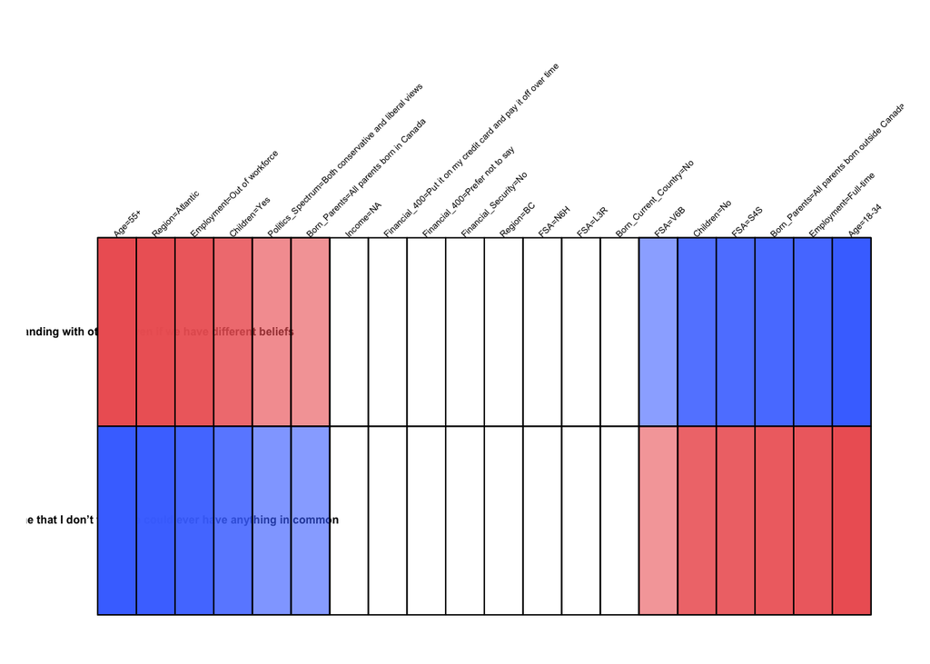

### By statictical results with unweighted data

```
##
## Link between the cluster variable and the categorical variables (chi-square test)
## =================================================================================
##                           p.value df
## Age                  1.788657e-09  2
## Region               1.371657e-03  3
## Employment           2.469252e-03  3
## Children             4.595694e-03  2
## Politics_Spectrum    1.405284e-02  2
## Born_Parents         1.575864e-02  4
## Born_Current_Country 2.545257e-02  2
##
## Description of each cluster by the categories
## =============================================
## $`I seek to find common understanding with others, even if we have different beliefs`
##                                                                  Cla/Mod
## Age=55+                                                         80.98918
## Region=Atlantic                                                 82.14286
## Employment=Out of workforce                                     78.77759
## Children=Yes                                                    77.05678
## Politics_Spectrum=Both conservative and liberal views           77.32240
## Born_Parents=All parents born in Canada                         76.68919
## Income=NA                                                       80.79470
## Financial_400=Put it on my credit card and pay it off over time 67.75956
## Financial_400=Prefer not to say                                 60.41667
## Financial_Security=No                                           69.64286
## Region=BC                                                       68.75000
## FSA=N6H                                                          0.00000
## FSA=L3R                                                          0.00000
## Born_Current_Country=No                                         67.32283
## FSA=V6B                                                          0.00000
## Children=No                                                     70.00000
## FSA=S4S                                                          0.00000
## Born_Parents=All parents born outside Canada                    68.59345
## Employment=Full-time                                            69.48640
## Age=18-34                                                       62.31003
##                                                                   Mod/Cla
## Age=55+                                                         45.017182
## Region=Atlantic                                                 21.735395
## Employment=Out of workforce                                     39.862543
```

[output cut: 172 more lines]

```
## FSA=V6B                                                          2.834681
## Born_Current_Country=No                                          2.558684
## FSA=N6H                                                          2.372378
## FSA=L3R                                                          2.372378
## Region=BC                                                        2.246165
## Financial_Security=No                                            2.193783
## Financial_400=Prefer not to say                                  2.066865
## Financial_400=Put it on my credit card and pay it off over time  1.976996
## Income=NA                                                       -2.062987
## Born_Parents=All parents born in Canada                         -2.850090
## Politics_Spectrum=Both conservative and liberal views           -2.880433
## Children=Yes                                                    -3.126329
## Employment=Out of workforce                                     -3.428108
## Region=Atlantic                                                 -3.767489
## Age=55+                                                         -5.403007
```

### By plots with weighted data

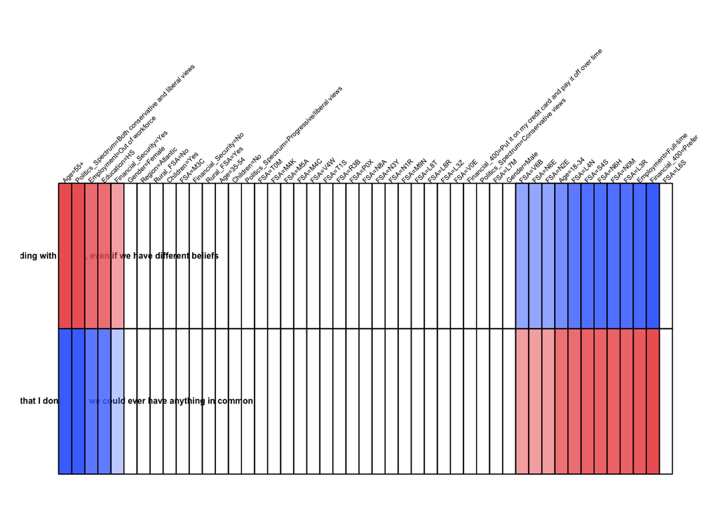

### By statictical results with weighted data

```
##
## Link between the cluster variable and the categorical variables (chi-square test)
## =================================================================================
##                         p.value  df
## Age                4.035005e-06   2
## Financial_400      4.283902e-05   9
## FSA                5.097726e-05 704
## Politics_Spectrum  1.110622e-04   2
## Employment         4.402664e-03   3
## Education          9.526024e-03   4
## Financial_Security 1.926139e-02   2
## Gender             2.259975e-02   2
## Rural_FSA          2.842572e-02   1
##
## Description of each cluster by the categories
## =============================================
## $`I seek to find common understanding with others, even if we have different beliefs`
##                                                                   Cla/Mod
## Age=55+                                                          80.46049
## Politics_Spectrum=Both conservative and liberal views            78.33260
## Employment=Out of workforce                                      77.39909
## Education=HS                                                     76.91735
## Financial_Security=Yes                                           75.59141
## Gender=Female                                                    75.87526
## Region=Atlantic                                                  81.03712
## Rural_FSA=No                                                     74.00309
## Children=Yes                                                     75.48426
## FSA=M3C                                                         100.00000
## Financial_Security=No                                            69.59511
## Rural_FSA=Yes                                                    65.82520
## Age=35-54                                                        69.89655
## Children=No                                                      70.77223
## Politics_Spectrum=Progressive/liberal views                      69.52953
## FSA=T0M                                                          18.63027
## FSA=M4K                                                          16.55623
## FSA=M5A                                                          37.36458
## FSA=M4C                                                          28.69293
## FSA=V4W                                                           0.00000
## FSA=T1S                                                           0.00000
## FSA=R3B                                                           0.00000
```

[output cut: 434 more lines]

```
## Politics_Spectrum=Progressive/liberal views                      2.296791
## Children=No                                                      2.168375
## Age=35-54                                                        2.091240
## Rural_FSA=Yes                                                    2.088779
## Financial_Security=No                                            2.052722
## FSA=M3C                                                         -2.016530
## Children=Yes                                                    -2.024196
## Rural_FSA=No                                                    -2.088779
## Region=Atlantic                                                 -2.225176
## Gender=Female                                                   -2.404004
## Financial_Security=Yes                                          -2.677286
## Education=HS                                                    -3.065375
## Employment=Out of workforce                                     -3.100458
## Politics_Spectrum=Both conservative and liberal views           -4.260333
## Age=55+                                                         -5.039065
```

## 4.2. By value varibles

### By plots with unweighted data

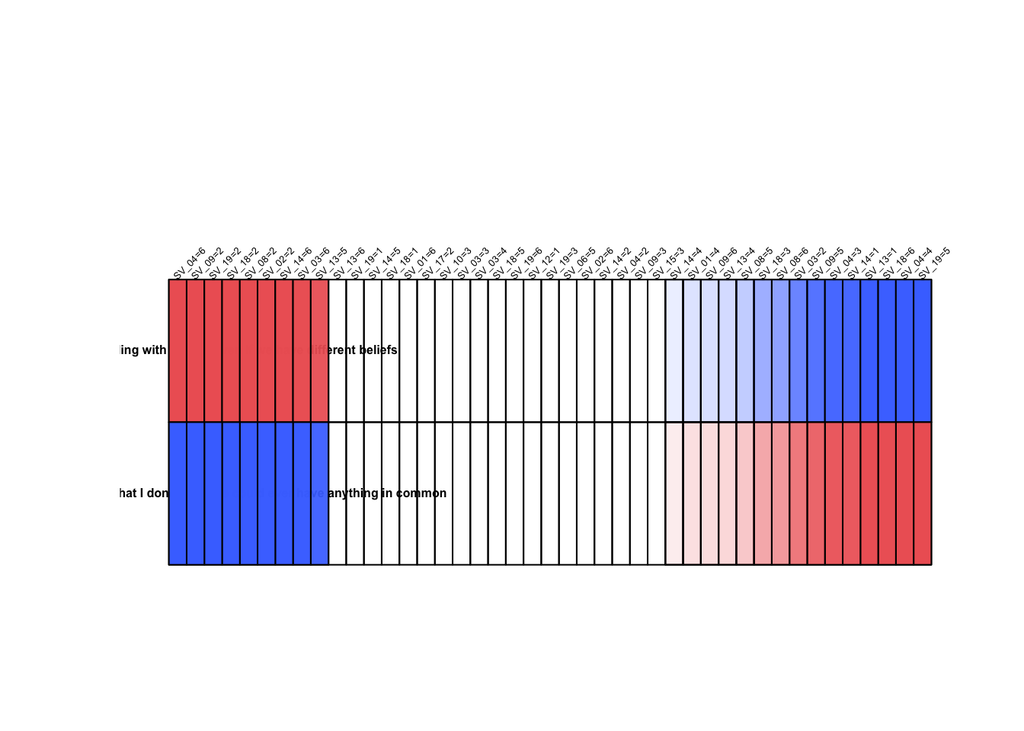

### By statictical results with unweighted data

```
##
## Link between the cluster variable and the categorical variables (chi-square test)
## =================================================================================
##            p.value df
## SV_04 1.551868e-10  5
## SV_19 1.545953e-09  5
## SV_14 3.261627e-08  5
## SV_18 7.145873e-08  5
## SV_13 8.626368e-08  5
## SV_09 2.212794e-07  5
## SV_08 1.770745e-05  5
## SV_03 2.570667e-05  5
## SV_02 1.548396e-04  5
## SV_01 2.558262e-02  5
##
## Description of each cluster by the categories
## =============================================
## $`I seek to find common understanding with others, even if we have different beliefs`
##          Cla/Mod    Mod/Cla    Global      p.value    v.test
## SV_04=6 81.80077 36.6838488 33.142857 3.097847e-07  5.117395
## SV_09=2 82.57576 28.0927835 25.142857 3.155176e-06  4.660451
## SV_19=2 80.83832 34.7938144 31.809524 1.374258e-05  4.347934
## SV_18=2 81.19266 30.4123711 27.682540 3.278405e-05  4.153212
## SV_08=2 82.23496 24.6563574 22.158730 3.774318e-05  4.120878
## SV_02=2 82.66667 21.3058419 19.047619 7.726229e-05  3.952737
## SV_14=6 81.36483 26.6323024 24.190476 1.004242e-04  3.889565
## SV_03=6 81.55620 24.3127148 22.031746 1.700011e-04  3.759871
## SV_13=5 78.84615 38.7457045 36.317460 6.770868e-04  3.398693
## SV_13=6 79.45205 19.9312715 18.539683 1.532482e-02  2.424610
## SV_19=1 80.00000 16.4948454 15.238095 1.764228e-02  2.373041
## SV_14=5 77.68763 32.9037801 31.301587 2.028993e-02  2.320943
## SV_18=1 79.23077 17.6975945 16.507937 3.023835e-02  2.166954
## SV_01=6 77.86260 26.2886598 24.952381 3.782005e-02  2.076800
## SV_17=2 81.51261  8.3333333  7.555556 4.516926e-02  2.003075
## SV_10=3 69.97319 22.4226804 23.682540 4.999909e-02 -1.959972
## SV_03=3 70.07673 23.5395189 24.825397 4.889000e-02 -1.969550
## SV_03=4 68.53448 13.6597938 14.730159 4.700620e-02 -1.986244
## SV_18=5 67.87565 11.2542955 12.253968 4.549921e-02 -2.000010
## SV_19=6 62.85714  3.7800687  4.444444 3.779690e-02 -2.077050
## SV_12=1 61.64384  3.8659794  4.634921 1.890945e-02 -2.347311
```

[output cut: 53 more lines]

```
## SV_17=2 18.48739  5.352798  7.555556 4.516926e-02 -2.003075
## SV_01=6 22.13740 21.167883 24.952381 3.782005e-02 -2.076800
## SV_18=1 20.76923 13.138686 16.507937 3.023835e-02 -2.166954
## SV_14=5 22.31237 26.763990 31.301587 2.028993e-02 -2.320943
## SV_19=1 20.00000 11.678832 15.238095 1.764228e-02 -2.373041
## SV_13=6 20.54795 14.598540 18.539683 1.532482e-02 -2.424610
## SV_13=5 21.15385 29.440389 36.317460 6.770868e-04 -3.398693
## SV_03=6 18.44380 15.571776 22.031746 1.700011e-04 -3.759871
## SV_14=6 18.63517 17.274939 24.190476 1.004242e-04 -3.889565
## SV_02=2 17.33333 12.652068 19.047619 7.726229e-05 -3.952737
## SV_08=2 17.76504 15.085158 22.158730 3.774318e-05 -4.120878
## SV_18=2 18.80734 19.951338 27.682540 3.278405e-05 -4.153212
## SV_19=2 19.16168 23.357664 31.809524 1.374258e-05 -4.347934
## SV_09=2 17.42424 16.788321 25.142857 3.155176e-06 -4.660451
## SV_04=6 18.19923 23.114355 33.142857 3.097847e-07 -5.117395
```

### By plots with weighted data

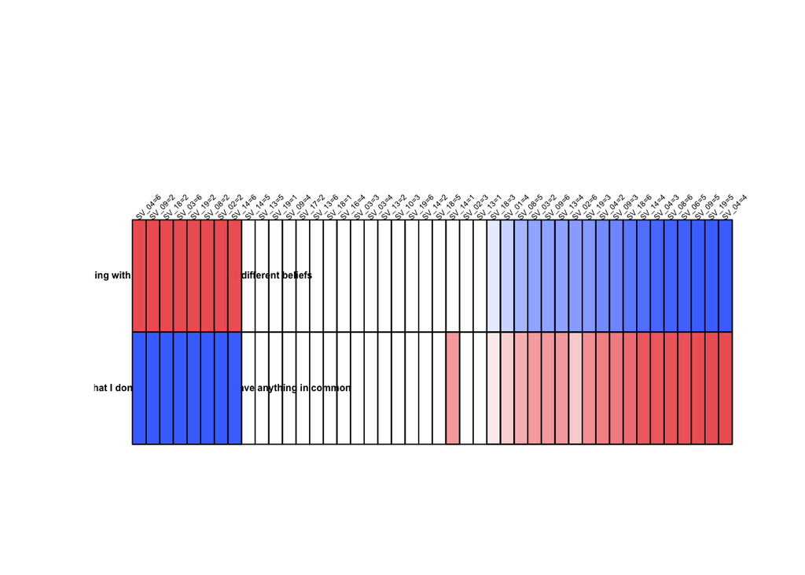

### By statictical results with weighted data

```
##
## Link between the cluster variable and the categorical variables (chi-square test)
## =================================================================================
##            p.value df
## SV_04 2.499670e-10  5
## SV_09 7.462721e-10  5
## SV_19 1.011018e-08  5
## SV_14 9.876813e-08  5
## SV_18 2.296373e-07  5
## SV_08 7.623751e-07  5
## SV_03 1.117379e-05  5
## SV_13 4.174086e-05  5
## SV_02 5.421941e-05  5
## SV_06 5.095163e-03  5
## SV_01 2.092421e-02  5
##
## Description of each cluster by the categories
## =============================================
## $`I seek to find common understanding with others, even if we have different beliefs`
##          Cla/Mod    Mod/Cla    Global      p.value    v.test
## SV_04=6 80.95368 37.5253663 33.926981 2.694973e-07  5.143618
## SV_09=2 82.04391 28.0270389 25.002749 3.223937e-06  4.656012
## SV_18=2 81.10886 30.9899338 27.964641 6.323323e-06  4.515280
## SV_03=6 82.45872 25.3700569 22.518619 6.980992e-06  4.494267
## SV_19=2 80.60542 33.4046501 30.331898 1.010377e-05  4.414941
## SV_08=2 81.95536 25.1009723 22.416617 1.860868e-05  4.280962
## SV_02=2 82.80199 20.9785621 18.543505 1.980222e-05  4.267109
## SV_14=6 80.56838 27.1079621 24.625731 1.684758e-04  3.762125
## SV_14=5 77.48862 31.8435823 30.077442 1.247469e-02  2.498424
## SV_13=5 76.99327 37.3161053 35.473204 1.308138e-02  2.481546
## SV_19=1 79.54806 17.7360721 16.318669 1.313214e-02  2.480165
## SV_09=4 78.56858 22.5065965 20.966107 1.373296e-02  2.464173
## SV_17=2 82.46500  8.1485999  7.232197 1.740335e-02  2.378074
## SV_13=6 78.57274 21.1138012 19.667603 2.009720e-02  2.324528
## SV_18=1 78.57201 18.2728688 17.021418 2.317580e-02  2.270524
## SV_16=4 77.64151 23.5245259 22.176031 3.213838e-02  2.142685
## SV_03=3 69.38854 25.0656560 26.439195 4.677166e-02 -1.988362
## SV_03=4 68.14481 14.5249915 15.600552 4.322830e-02 -2.021497
## SV_13=2 58.38648  2.1839220  2.737674 3.106067e-02 -2.156295
## SV_10=3 68.98943 23.0137978 24.415331 2.733375e-02 -2.206718
```

[output cut: 55 more lines]

```
## SV_18=1 21.42799 13.604869 17.021418 2.317580e-02 -2.270524
## SV_17=2 17.53500  4.730350  7.232197 1.740335e-02 -2.378074
## SV_09=4 21.43142 16.760459 20.966107 1.373296e-02 -2.464173
## SV_13=6 21.42726 15.719376 19.667603 1.341111e-02 -2.472662
## SV_19=1 20.45194 12.449056 16.318669 1.313214e-02 -2.480165
## SV_13=5 23.00673 30.441950 35.473204 1.308138e-02 -2.481546
## SV_14=5 22.51138 25.255750 30.077442 1.247469e-02 -2.498424
## SV_14=6 19.43162 17.849062 24.625731 9.593644e-05 -3.900646
## SV_02=2 17.19801 11.895622 18.543505 1.980222e-05 -4.267109
## SV_08=2 18.04464 15.088134 22.416617 1.860868e-05 -4.280962
## SV_19=2 19.39458 21.943065 30.331898 1.010377e-05 -4.414941
## SV_18=2 18.89114 19.705373 27.964641 6.323323e-06 -4.515280
## SV_03=6 17.54128 14.733986 22.518619 3.484249e-06 -4.639991
## SV_09=2 17.95609 16.746218 25.002749 3.223937e-06 -4.656012
## SV_04=6 19.04632 24.103130 33.926981 5.210776e-07 -5.018385
```